# Cars

# INTRODUCTION ET HYPOTHESES DE DEPART

Dans la phase de rassemblement des données, nous sommes partis à la chasse aux voitures les mieux vendues en Tunisie pendant l’année 2017, et nous avons sélectionné 4 critères de choix majeurs. La consommation (MPG), le prix (Cost), le nombre de chevaux dynamiques (HP), et le poids (Weight).

## DESCRIPTIF DES DONNEES SELECTIONNEES

top5cars.csv: Contient les 5 voitures les mieux vendues en 2017 allcars.csv: Contient toutes les voitures du monde sauf quelques exceptions

Colonnes:

MPG: Miles per Gallons, soit nombre de Miles (aprx 1.5 km) par Gallons (aprx 4.5 L)

Cost: Prix de vente exprimé en dollars. Il s’agit du prix de revene recommandé par le fabriquant de la voiture.

HP: Nombre de chevaux dynamiques.

Weight: Poids de la voiture en Kg

## HYPOTHESES DE DEPART ET INTUITIONS

D’après nos connaissances en voiture et un sondage d’un échantillon de mécaniciens (tous les mécaniciens sur la route entre Manouba et la Petite Ariana, en passant par la Mnihla, Ghazela et Ettadhamon) et de taxis (notre équipe est un grand consommateur des services des taxis), nous avons les hypothèses de départ suivantes:

### H1:

Plus le Cost est élevé et moins le Tunisien veut acheter la voiture (corrélation forte négative)

### H2:

Plus le MPG est élevé et plus le Tunisien veut acheter la voiture (corrélation forte positive).

### H3-1:

Plus le HP est élevé et plus le Tunisien veut acheter la voiture (Corrélation faible positive).

### H3-2:

En revanche, plus le HP est élevé et plus le MPG est faible donc moins le Tunisien veut acheter la voiture.

### H4-1:

Plus le Weight est élevé et plus le Tunisien veut acheter la voiture (Corrélation faible positive).

### H4-2:

En revanche plus le Weight est élevé et plus le MPG est faible donc moins le Tunisien veut acheter la voiture.

## OBJECTIFS PRELIMINAIRES

En partant de ces hypothèses de départ, on va essayer de créer un profil de la voiture idéale du Tunisien et identifier ses principales caractéristiques. Par la suite, on va faire une segmentation de toutes les voitures du monde (en retirant certaines marques, nous expliquerons par la suite), et trouver le segment qui correspond le mieux à la voiture idéale du tunisien.

Sur ce:

# RECUPERATION ET EXPLORATION DES DONNEES

## RECUPERATION ET EXPLORATION DES DONNEES DES CINQ PREMIERES VOITURES

```r
cars <- read.table("top5cars.csv", header=T,fill=T, encoding="utf-8", sep=";", dec=",",quote = "", na.string="" )
cars$MPG=as.numeric(cars$MPG)
cars
```

```
##                Name Number  MPG  Cost  HP   Wg Origin
## 1      Renault Clio      5 36.0 17642 130 1215 Europe
## 2    Renault Symbol      4 50.0  9923  80  998 Europe
## 3 Hyundai Grand i10      3 57.0 12043  87  953   Asia
## 4     Kia Rio Sedan      2 29.5 10280 104 2403   Asia
## 5       Ford Fiesta      1 30.0 14115 120 1113    USA
```

On va retirer les variables qualitatives pour isoler les quatre paramètres qui nous importent. Nous allons stocker les quali de côté pour pouvoir faire une identification par la suite

```r
carsQuali=cars[,(names(cars) %in% c("Number","Name","Origin"))]
cars=cars[,!(names(cars) %in% c("Number","Name","Origin"))]
```

# RECUPERATION ET EXPLORATION DES DONNEES DES VOITURES DU MONDE

```r
allcars <- read.table("allcars.csv", header=T,fill=T, encoding="utf-8", sep=";", dec=",",quote = "", na.string="" )
summary(allcars)
```

```
##             Make                          Model         Type
##  Toyota       : 28    C240 4dr               :  2   Hybrid:  3
##  Chevrolet    : 27    C320 4dr               :  2   Sedan :262
##  Mercedes-Benz: 26    G35 4dr                :  2   Sports: 49
##  Ford         : 23    3.5 RL 4dr             :  1   SUV   : 60
##  BMW          : 20    3.5 RL w/Navigation 4dr:  1   Truck : 24
##  Audi         : 19    300M 4dr               :  1   Wagon : 30
##  (Other)      :285   (Other)                 :419
##     Origin         Cost              HP             MPG2
##  Asia  :158   Min.   : 10280   Min.   : 73.0   Min.   :10.00
##  Europe:123   1st Qu.: 20334   1st Qu.:165.0   1st Qu.:17.00
##  USA   :147   Median : 27635   Median :210.0   Median :19.00
##               Mean   : 32775   Mean   :215.9   Mean   :20.06
##               3rd Qu.: 39205   3rd Qu.:255.0   3rd Qu.:21.25
##               Max.   :192465   Max.   :500.0   Max.   :60.00
##
##       MPG1             Wg        OriginQuanti
##  Min.   :12.00   Min.   :1850   Min.   :1.000
##  1st Qu.:24.00   1st Qu.:3104   1st Qu.:1.000
##  Median :26.00   Median :3474   Median :2.000
##  Mean   :26.84   Mean   :3578   Mean   :2.056
##  3rd Qu.:29.00   3rd Qu.:3978   3rd Qu.:3.000
##  Max.   :66.00   Max.   :7190   Max.   :3.000
##
```

On remarque qu’il y a deux valeurs de MPG. Il s’agit du MPG en autoroute et du MPG en ville. On va prendre la valeur du MPG global (qui est en fait la moyenne des deux)

```r
allcars$MPG=(allcars$MPG1+allcars$MPG2)/2
allcarsQuali=allcars[,(names(allcars) %in% c("Make","Type","Model","Origin" ))]
allcars=allcars[,names(allcars) %in% c("MPG","Wg", "HP", "Cost")]
```

# EXPLORATION ET VERIFICATION DE NOS HYPOTHESES DE DEPART

Voyons voir les moyennes des quatre indicateurs clé

```r
summary(allcars)
```

```
##       Cost              HP              Wg            MPG
##  Min.   : 10280   Min.   : 73.0   Min.   :1850   Min.   :11.00
##  1st Qu.: 20334   1st Qu.:165.0   1st Qu.:3104   1st Qu.:20.50
##  Median : 27635   Median :210.0   Median :3474   Median :23.00
##  Mean   : 32775   Mean   :215.9   Mean   :3578   Mean   :23.45
##  3rd Qu.: 39205   3rd Qu.:255.0   3rd Qu.:3978   3rd Qu.:25.50
##  Max.   :192465   Max.   :500.0   Max.   :7190   Max.   :63.00
```

Et comparons les avec celles des cinq premières voitures

```r
summary(cars)
```

```
##       MPG            Cost             HP              Wg
##  Min.   :29.5   Min.   : 9923   Min.   : 80.0   Min.   : 953
##  1st Qu.:30.0   1st Qu.:10280   1st Qu.: 87.0   1st Qu.: 998
##  Median :36.0   Median :12043   Median :104.0   Median :1113
##  Mean   :40.5   Mean   :12801   Mean   :104.2   Mean   :1336
##  3rd Qu.:50.0   3rd Qu.:14115   3rd Qu.:120.0   3rd Qu.:1215
##  Max.   :57.0   Max.   :17642   Max.   :130.0   Max.   :2403
```

Un simple regard des moyennes des 4 variables prouve déjà partiellement nos hypothèses. H1 et H2 sont vérifiées par la faiblesse relative de la moyenne du coût des cinq premières voitures par rapport à celle de toutes les voitures du monde. Dans le cas où vous êtes friand de la visualisation graphique, voyons voir les boxplots:

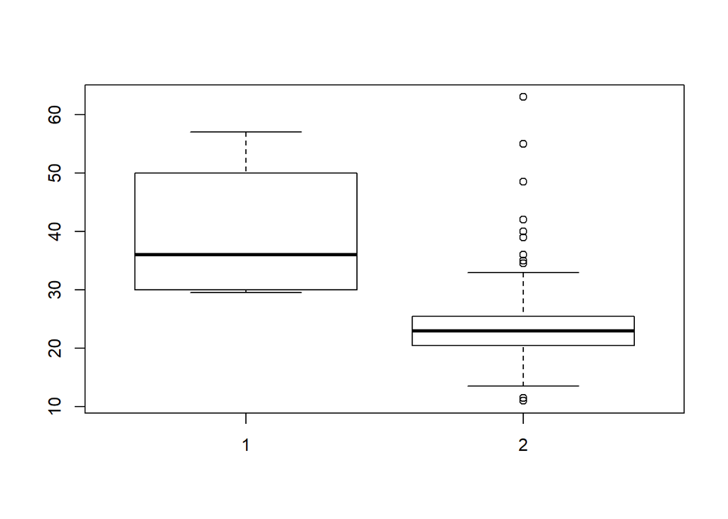

```r
boxplot(cars$MPG, allcars$MPG)
```

On passe au coût:

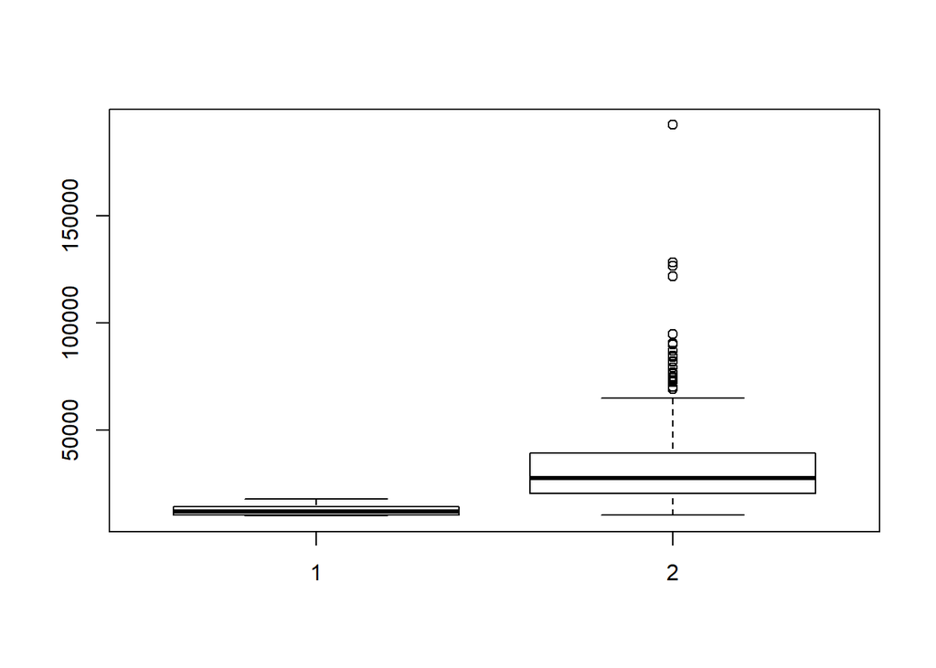

```r
boxplot(cars$Cost, allcars$Cost)
```

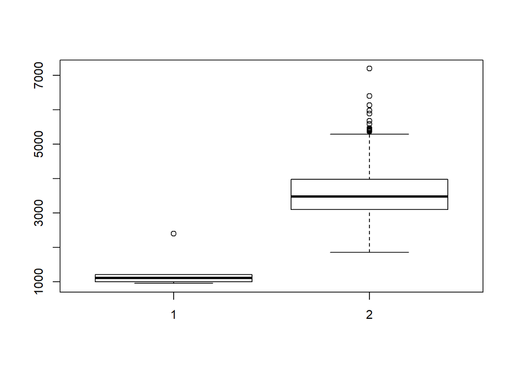

```r
boxplot(cars$Wg, allcars$Wg)
```

Voyons voir le nombre de chevaux dynamiques:

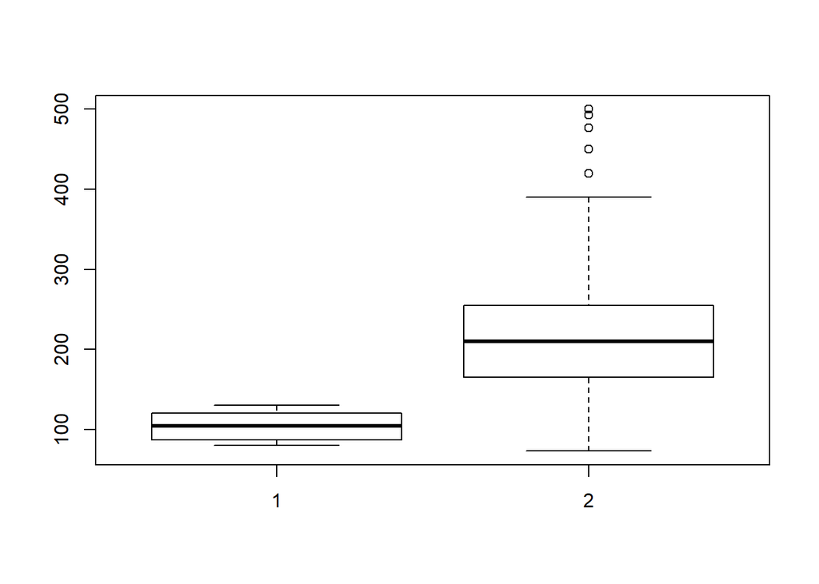

```r
boxplot(cars$HP, allcars$HP)
```

# PREPARATION DES DONNES

Allez, place à la préparation des données! On commence par fusionner nos datasets:

```r
mergedcars <- rbind(allcars,cars)
```

Si vous vous souvenez du summary

```r
summary(mergedcars)
```

```
##       Cost              HP              Wg            MPG
##  Min.   :  9923   Min.   : 73.0   Min.   : 953   Min.   :11.00
##  1st Qu.: 20290   1st Qu.:163.0   1st Qu.:3086   1st Qu.:20.50
##  Median : 27490   Median :210.0   Median :3470   Median :23.00
##  Mean   : 32544   Mean   :214.6   Mean   :3552   Mean   :23.65
##  3rd Qu.: 38830   3rd Qu.:250.0   3rd Qu.:3966   3rd Qu.:25.50
##  Max.   :192465   Max.   :500.0   Max.   :7190   Max.   :63.00
```

et j’ajoute un boxplot au cas où vous n’aimez pas les chiffres

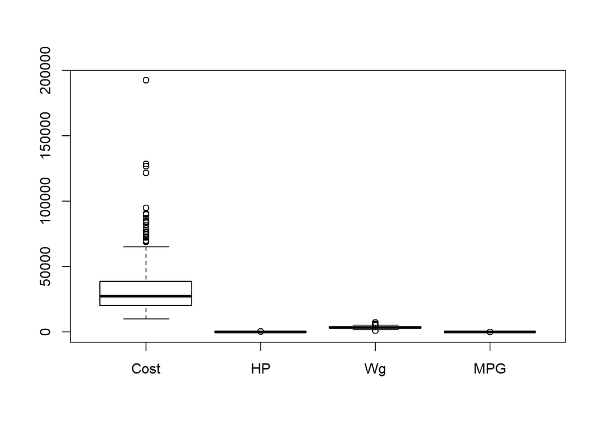

```r
boxplot(mergedcars)
```

vous remarquerez que les unités sont complètement différentes. Miles/Gallon coexiste avec Kilogramme, Horse et Dollar. On ne peut pas travailler dans ces conditions, car les indices au maximum ridiculement élevé (Cost) auront un poids plus lourd dans la segmentation.

On fait donc une normalisation: Soustraire la moyenne et diviser par l’écart-type, et soudain, tout le monde est à pied d’égalité.

On prend tout de même la peine de mettre de côté les valeurs non normalisées.

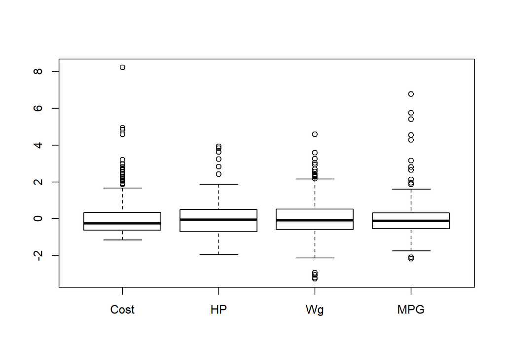

```r
originalPrescale=mergedcars
mergedcars<-scale(mergedcars)
boxplot(mergedcars)
```

Tout va bien maintenant! On note tout de même la présence de cas aberrants qu’il faudra tenir en compte par la suite.

Pour pouvoir récupérer les variables qualitatives plus tard, on vas revoir le format des données des données qualitatives des 5 meilleures voitures.

```r
Make=c("Renault", "Renault", "Hyundai", "Kia", "Ford")
Type=c("Sedan","Sedan","Sedan","Sedan","Sedan")
Origin=c("Europe", "Europe", "Asia", "Asia", "USA")
Model=carsQuali$Name
NewcarsQuali=data.frame(Make, Type,Origin,Model)
NewcarsQuali
```

```
##      Make  Type Origin             Model
## 1 Renault Sedan Europe      Renault Clio
## 2 Renault Sedan Europe    Renault Symbol
## 3 Hyundai Sedan   Asia Hyundai Grand i10
## 4     Kia Sedan   Asia     Kia Rio Sedan
## 5    Ford Sedan    USA       Ford Fiesta
```

On va à présent fusionner les deux datasets de données qualitatives. Ensuite, nous allons ajouter les concessionnaires de chaque marque de voiture.

```r
mergedQuali <-rbind(allcarsQuali, NewcarsQuali)
mergedQuali$Con="Unknown"
mergedQuali$Make=as.character(mergedQuali$Make)
mergedQuali[which(mergedQuali$Make =="Toyota"),][5]="BSB"
mergedQuali[which(mergedQuali$Make =="Renault"),][5]="Artes"
mergedQuali[which(mergedQuali$Make =="Hyundai"),][5]="Alpha Hyundai"
mergedQuali[which(mergedQuali$Make =="Ford"),][5]="Alpha Ford"
mergedQuali[which(mergedQuali$Make =="Volkswagen"),][5]="Ennakl"
mergedQuali[which(mergedQuali$Make =="Audi"),][5]="Ennakl"
mergedQuali[which(mergedQuali$Make =="Kia"),][5]="City Cars"
mergedQuali[which(mergedQuali$Make =="Suzuki"),][5]="CAR PRO"
mergedQuali[which(mergedQuali$Make =="Mitsubishi"),][5]="SAM"
mergedQuali[which(mergedQuali$Make =="Honda"),][5]="JMC"
mergedQuali[which(mergedQuali$Make =="Nissan"),][5]="ADEV"
mergedQuali[which(mergedQuali$Make =="Volvo"),][5]="Sayara"
mergedQuali[which(mergedQuali$Make =="Saab"),][5]="Pas de concessionnaire"
mergedQuali[which(mergedQuali$Make =="Scion"),][5]="Pas de concessionnaire"
mergedQuali[which(mergedQuali$Make =="Lexus"),][5]="Pas de concessionnaire"
mergedQuali[which(mergedQuali$Make =="Subaru"),][5]="Pas de concessionnaire"
mergedQuali[which(mergedQuali$Make =="Mazda"),][5]="Economic Auto"
mergedQuali[which(mergedQuali$Make =="Mercedes-Benz"),][5]="Le Moteur"
mergedQuali[which(mergedQuali$Make =="MINI"),][5]="Ben Jemaa Motors"
mergedQuali[which(mergedQuali$Make =="BMW"),][5]="Ben Jemaa Motors"
mergedQuali[which(mergedQuali$Make =="Infiniti"),][5]="Pas de concessionnaire"
mergedQuali[which(mergedQuali$Make =="Chevrolet"),][5]="Afrique Auto"
mergedQuali[which(mergedQuali$Make =="Saturn"),][5]="Pas de concessionnaire"
mergedQuali[which(mergedQuali$Make =="Porsche"),][5]="Ennakl"
mergedQuali[which(mergedQuali$Make =="Mercury"),][5]="Pas de concessionnaire"
mergedQuali[which(mergedQuali$Make =="Lincoln"),][5]="Pas de concessionnaire"
mergedQuali[which(mergedQuali$Make =="Land Rover"),][5]="Alpha International"
mergedQuali[which(mergedQuali$Make =="Jaguar"),][5]="Alpha International"
mergedQuali[which(mergedQuali$Make =="Chrysler"),][5]="Italcar"
mergedQuali[which(mergedQuali$Make =="Dodge"),][5]="Italcar"
mergedQuali[which(mergedQuali$Make =="GMC"),][5]="Afrique Auto"
mergedQuali[which(mergedQuali$Make =="Buick"),][5]="Afrique Auto"
mergedQuali[which(mergedQuali$Make =="Cadillac"),][5]="Afrique Auto"
mergedQuali[which(mergedQuali$Make =="Acura"),][5]="JMC"
```

Tâche assez ingrate, mais absolument nécessaire. Après tout, notre objectif est au delà du clustering des voitures, mais bien de voir quels concessionnaires vendent les voitures que cherche le tunisien

```r
tail(mergedQuali)
```

```
##        Make             Model  Type Origin           Con
## 428   Volvo              XC70 Wagon Europe        Sayara
## 429 Renault      Renault Clio Sedan Europe         Artes
## 430 Renault    Renault Symbol Sedan Europe         Artes
## 431 Hyundai Hyundai Grand i10 Sedan   Asia Alpha Hyundai
## 432     Kia     Kia Rio Sedan Sedan   Asia     City Cars
## 433    Ford       Ford Fiesta Sedan    USA    Alpha Ford
```

Vous voyez les cinq dernières lignes? Elles correspondent aux voitures idéales.

# SEGMENTATION DES VOITURES

On commence par déterminer le nombre de clusters optimal par le calcul de la variance intra groupes.

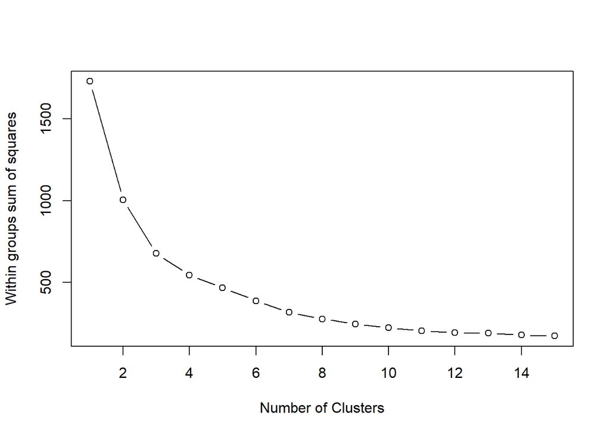

```r
wss <- (nrow(mergedcars)-1)*sum(apply(mergedcars,2,var))
for (i in 2:15) wss[i] <- sum(kmeans(mergedcars,
                                     centers=i)$withinss)
plot(1:15, wss, type="b", xlab="Number of Clusters",
     ylab="Within groups sum of squares")
```

D’après le critère de coude, on voit que la cassure a lieu lorsqu’on dispose de 3 clusters. Il est temps d’appliquer un algorithme de clustering !

Pam-K semble être le plus adapté à nos besoins. Il est en effet assez solide quant il s’agit de traiter les cas aberrants. Et si vous vous souvenez des boxplots, on voit qu’il y a des cas aberrants dans les quatre mesures.

On va utiliser la librairie FPC pour PAMK et cluster pour visualiser nos clusters

```r
library(fpc)
library(cluster)
```

On lance PAMK et on fait la moyenne des attributs dans les différents clusters.

```r
fit_pam <- pamk(mergedcars, 3) # 3 cluster solution
aggregate(mergedcars,by=list(fit_pam$pamobject$clustering),FUN=mean)
```

```
##   Group.1       Cost          HP          Wg       MPG
## 1       1  1.2086979  1.34421659  1.05133018 -0.858232
## 2       2 -0.8236978 -1.12652504 -1.14607679  1.250513
## 3       3 -0.1718200 -0.09422878  0.04825211 -0.184316
```

Le Cluster 2 est celui qui nous intéresse. En effet, comme vous pouvez le voir, il concerne les voitures au coût le plus faible, mais aussi au nombre de chevaux dynamiques le plus faible, le poids le plus faible et la consommation la plus faible (plus grand MPG). Maintenant on va visualiser la séparation pour vérifier la validité de notre segmentation

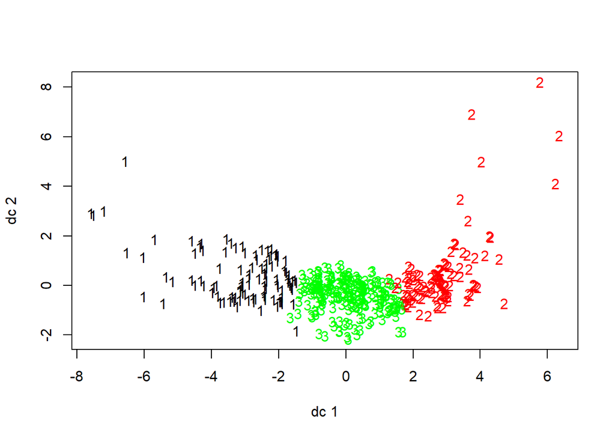

```r
plotcluster(mergedcars, fit_pam$pamobject$clustering)
```

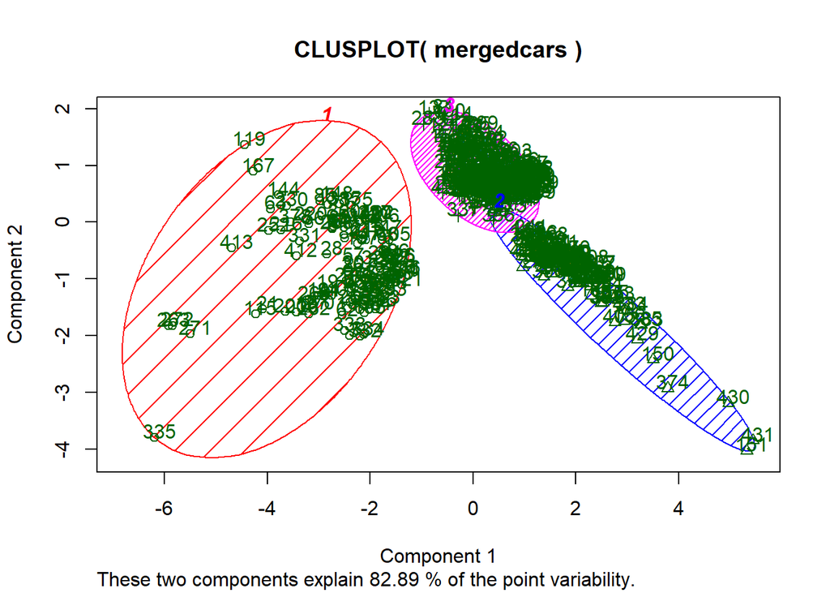

```r
mergedcars <- data.frame(mergedcars, fit_pam$pamobject$clustering)
clusplot(mergedcars, fit_pam$pamobject$clustering, color=TRUE, shade=TRUE, labels=2, lines=0)
```

Comme vous pouvez le voir, notre segmentation donne des clusters bien définis.

# SELECTION DES CONCESSIONNAIRES

```r
Quali_Perfect_Cluster =  mergedQuali[fit_pam$pamobject$clustering == 2,]


library(dplyr)
```

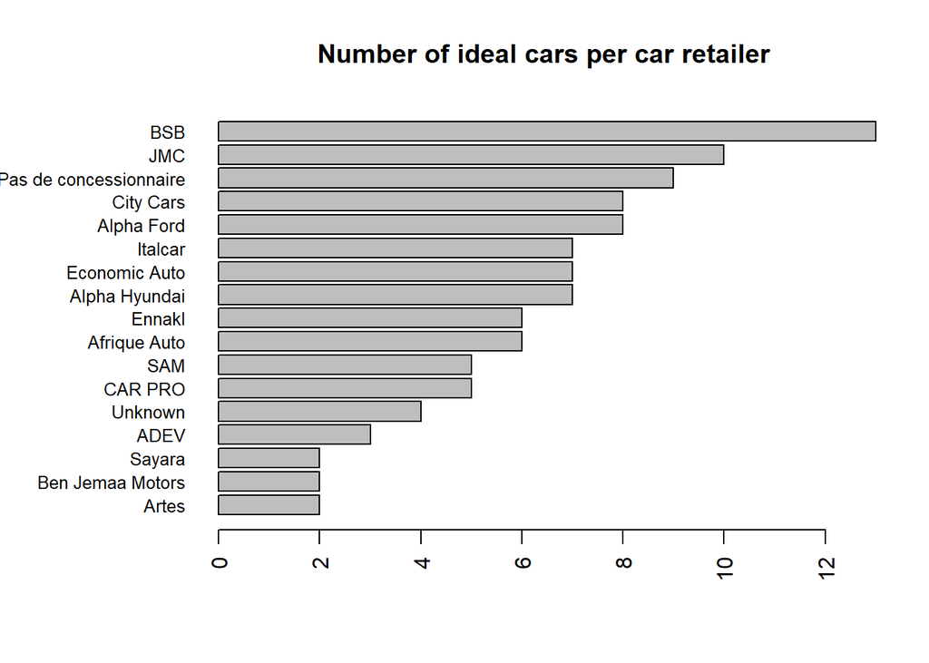

```r
Cons=Quali_Perfect_Cluster %>% select(Con,Make) %>% distinct
counter=aggregate(data.frame(count = Quali_Perfect_Cluster$Make), list(value = Quali_Perfect_Cluster$Con), length)
counter=counter[order(counter$count, decreasing = FALSE),]
par(las=2) # make label text perpendicular to axis
par(mar=c(5,8,4,2)) # increase y-axis margin.
barplot(counter$count, main="Number of ideal cars per car retailer", horiz=TRUE,
        names.arg=counter$value,  cex.names=0.8)
```

Le top 3 des concessionnaires ayant le plus grand nombre de voitures conformes au profil de la voiture idéale du Tunisien est BSB (Toyota), JMC (Honda) et City Cars (KIA)/Alpha Ford (Ford) en ex-aequo.

Comparons à présent ces résultats avec l’état des lieux: le quota actuel des entreprises.

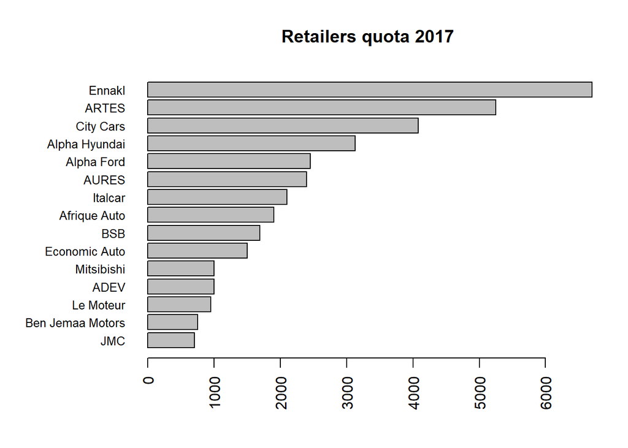

```r
Con=c("Ennakl","ARTES", "ADEV", "AURES", "Economic Auto", "Alpha Ford", "Alpha Hyundai", "Italcar", "Le Moteur", "City Cars", "BSB", "Afrique Auto", "Mitsibishi", "Ben Jemaa Motors", "JMC")

Quota_2017=c(6700,5250,1000,2396,1500,2453,3126,2100,950,4080,1692,1900,1000,750,700)

Con_Quota=data.frame(Con, Quota_2017)
Con_Quota=Con_Quota[order(Con_Quota$Quota_2017, decreasing = FALSE),]
par(las=2) # make label text perpendicular to axis
par(mar=c(5,8,4,2)) # increase y-axis margin.
barplot(Con_Quota$Quota_2017, main="Retailers quota 2017", horiz=TRUE,
        names.arg=Con_Quota$Con,  cex.names=0.8)
```

On remarque déjà l’écart entre les deux graphes, avec des compagnies dont les véhicules ne répondent pas forcément aux besoins du Tunisien au top de la chaîne.

# CONCLUSION ET PERSPECTIVES

Cette enquête permet de confirmer le profil de la voiture idéale du tunisien, et d’ouvrir la voie à une nouvelle façon d’attribuer les quotas aux concessionnaires automobiles: Selon le besoin réel du tunisien.